# p8105_hw5_ly2633

Leila Yan

2024-11-04

```r
# Load libraries
library(tidyverse)
```

```r
library(ggplot2)
```

# Problem 1

# Problem 2

Question: Conduct a simulation to explore power in a one-sample t-test. For each dataset, save 𝜇̂ and the p-value arising from a test of 𝐻:𝜇=0using 𝛼=0.05 Hint: to obtain the estimate and p-value, use broom::tidy to clean the output of t.test.

```r
# Conduct a simulation to explore power in one-sample t-test
onesample_t_test = function(mu){
  n=30
  sigma = 5
  x=rnorm(n,mean=mu,sd=sigma)

  t_test_output = t.test(x,mu=0, conf.level = 0.95)|>
              broom::tidy()

  return(t_test_output)
}

onesample_t_test_sim =
  expand_grid(
    mu = c(0:6),
    iter = 1:5000
  ) %>%
  mutate(
    ttest_output = map(mu, onesample_t_test)
  ) %>%
  unnest(ttest_output)
```

Question: Make a plot showing the proportion of times the null was rejected (the power of the test) on the y axis and the true value of 𝜇on the x axis. Describe the association between effect size and power.

[output not shown]

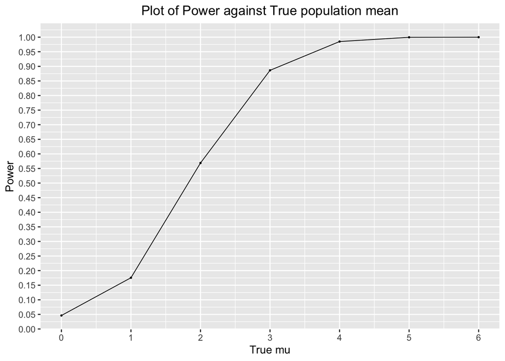

```r
onesample_t_test_sim %>%
  mutate(
    reject = ifelse(p.value < 0.05, 1, 0)
  )%>%
  group_by(mu,reject) %>%
  filter(reject == 1)%>%
  summarise(reject_count =n())%>%
  mutate(power = reject_count/5000)%>%
  ggplot(aes(x=mu, y=power))+
  geom_point(size=0.4)+
  geom_line(size=0.35)+
  scale_x_continuous(breaks=0:6)+
  scale_y_continuous(breaks=seq(0,1, by=0.05))+
  labs(title="Plot of Power against True population mean", x="True mu", y="Power")+
  theme(plot.title=element_text(hjust=0.5))
```

Answers: We see a clear positive association between effect size and power. When the true value of μ is small, the power is low, meaning the test has a lower chance of detecting an effect and rejecting the null hypothesis. As μ increases, power rises as well, approaching 1 for higher values of μ. This trend indicates that with larger effect sizes, it becomes easier for the test to identify a difference from the null, leading to a higher probability of rejection. This behavior is expected in hypothesis testing; small effects are more challenging to detect due to their similarity to random noise, resulting in lower power. Conversely, as the effect size grows, the distinction from the null becomes more pronounced, allowing the test to detect the effect with greater accuracy, thus increasing power.

Question: Make a plot showing the average estimate of 𝜇̂ on the y axis and the true value of 𝜇on the x axis. Make a second plot (or overlay on the first) the average estimate of 𝜇̂ only in samples for which the null was rejected on the y axis and the true value of 𝜇on the x axis. Is the sample average of 𝜇̂ across tests for which the null is rejected approximately equal to the true value of 𝜇? Why or why not?

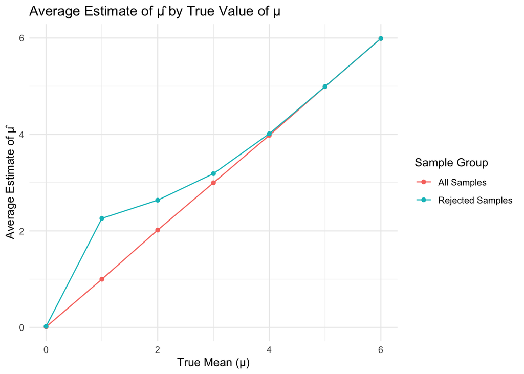

```r
onesample_t_test_summary = onesample_t_test_sim %>%
  mutate(
    reject = ifelse(p.value < 0.05, 1, 0)
  ) %>%
  group_by(mu) %>%
  summarise(
    avg_mu_hat_all = mean(estimate),
    avg_mu_hat_rejected = mean(estimate[reject == 1]),
    .groups = 'drop'
  )


ggplot(onesample_t_test_summary, aes(x = mu)) +
  geom_line(aes(y = avg_mu_hat_all, color = "All Samples")) +
  geom_point(aes(y = avg_mu_hat_all, color = "All Samples")) +
  geom_line(aes(y = avg_mu_hat_rejected, color = "Rejected Samples")) +
  geom_point(aes(y = avg_mu_hat_rejected, color = "Rejected Samples")) +
  labs(
    x = "True Mean (μ)",
    y = "Average Estimate of μ̂",
    title = "Average Estimate of μ̂ by True Value of μ",
    color = "Sample Group"
  ) +
  theme_minimal()
```

Answer: The average estimate closely follows the true𝜇, indicating an unbiased estimate. However, for samples where the null was rejected, the average estimate of 𝜇̂is consistently higher than the true𝜇 , particularly at lower values. Thus, the sample average across tests for which the null is rejected is not approximately equal to the true value of 𝜇. This is because when focusing only on tests that reject the null hypothesis, we introduce a selection bias that overrepresents larger observed effects, leading to an upward bias in the estimate of 𝜇.

# Problem 3

Describe the raw data.

```r
# load the data
homicide_data =
  read.csv("homicide-data.csv") %>%
  janitor::clean_names()
```

A description of the raw data: The raw dataset contains 12 variables and 52179 observations. It includes information on homicide cases across the states. Each row corresponds to a unique case identified by a UID. The columns include the report date, victim’s last and first names, race, age, and sex, along with the city and state. Additional fields provide geographic coordinates (latitude and longitude) of the incident location and the case’s disposition status (e.g., “Closed by arrest,” “Closed without arrest,” “Open/No arrest”). Some victim ages are recorded as “Unknown,” and a few entries lack latitude and longitude data.

```r
# Create a city_state variable (e.g. “Baltimore, MD”)
homicide_data = homicide_data %>%
  mutate(state = ifelse(city == "Seattle", "WA", state),
         city_state = paste(city, state, sep=", "))

# Summarize within cities to obtain the total number of homicides and the number of unsolved homicides(those for which the disposition is “Closed without arrest” or “Open/No arrest”).
totnumber_homicides =
  homicide_data %>%
  group_by(city_state) %>%
  summarise(totnumber_homicide = n())

totnumber_unsolved =
  homicide_data %>%
  group_by(city_state) %>%
  filter(disposition %in% c("Open/No arrest", "Closed without arrest"))|>
  summarise(totnumber_unsolved = n())

# Join the the total number of homicides and the number of unsolved homicides
total_counts =
  totnumber_homicides %>%
  left_join(totnumber_unsolved)
total_counts
```

```
## # A tibble: 51 × 3
##    city_state      totnumber_homicide totnumber_unsolved
##    <chr>                        <int>              <int>
##  1 Albuquerque, NM                378                146
##  2 Atlanta, GA                    973                373
##  3 Baltimore, MD                 2827               1825
##  4 Baton Rouge, LA                424                196
##  5 Birmingham, AL                 800                347
##  6 Boston, MA                     614                310
##  7 Buffalo, NY                    521                319
##  8 Charlotte, NC                  687                206
##  9 Chicago, IL                   5535               4073
## 10 Cincinnati, OH                 694                309
## # ℹ 41 more rows
```

For the city of Baltimore, MD, use the prop.test function to estimate the proportion of homicides that are unsolved; save the output of prop.test as an R object, apply the broom::tidy to this object and pull the estimated proportion and confidence intervals from the resulting tidy dataframe.

```r
# Use the prop.test function to estimate the proportion of homicides that are unsolved
# Estimated proportion and confidence intervals from the resulting tidy dataframe
Baltimore_data = total_counts %>%
  filter(city_state == "Baltimore, MD")

prop.test(n = pull(Baltimore_data, totnumber_homicide),
          x = pull(Baltimore_data, totnumber_unsolved)) %>%
  broom::tidy() %>%
  select(estimate, conf.low, conf.high)
```

```
## # A tibble: 1 × 3
##   estimate conf.low conf.high
##      <dbl>    <dbl>     <dbl>
## 1    0.646    0.628     0.663
```

Answer: The estimate is 0.6455607 and the confidence interval is (0.6275625, 0.6631599).

Now run prop.test for each of the cities in your dataset, and extract both the proportion of unsolved homicides and the confidence interval for each. Do this within a “tidy” pipeline, making use of purrr::map, purrr::map2, list columns and unnest as necessary to create a tidy dataframe with estimated proportions and CIs for each city.

```r
# Run prop.test and create a tidy dataframe with estimated proportions and CIs for each city
# Filter out rows with zero or missing values for homicide counts
city_proportion_estimates = total_counts %>%
  filter(totnumber_homicide > 0 & totnumber_unsolved >= 0) %>%
  mutate(test_result = purrr::map2(totnumber_unsolved, totnumber_homicide,
                                   ~ prop.test(.x, .y))) %>%
  mutate(test_result = purrr::map(test_result, broom::tidy)) %>%
  unnest(test_result) %>%
  select(city_state, estimate, conf.low, conf.high)

city_proportion_estimates
```

```
## # A tibble: 50 × 4
##    city_state      estimate conf.low conf.high
##    <chr>              <dbl>    <dbl>     <dbl>
##  1 Albuquerque, NM    0.386    0.337     0.438
##  2 Atlanta, GA        0.383    0.353     0.415
##  3 Baltimore, MD      0.646    0.628     0.663
##  4 Baton Rouge, LA    0.462    0.414     0.511
##  5 Birmingham, AL     0.434    0.399     0.469
##  6 Boston, MA         0.505    0.465     0.545
##  7 Buffalo, NY        0.612    0.569     0.654
##  8 Charlotte, NC      0.300    0.266     0.336
##  9 Chicago, IL        0.736    0.724     0.747
## 10 Cincinnati, OH     0.445    0.408     0.483
## # ℹ 40 more rows
```

Create a plot that shows the estimates and CIs for each city – check out geom_errorbar for a way to add error bars based on the upper and lower limits. Organize cities according to the proportion of unsolved homicides.

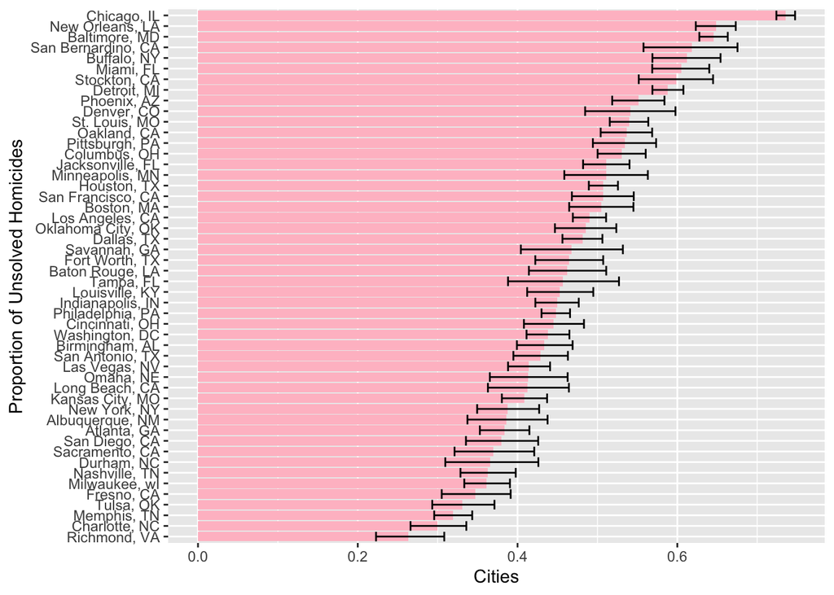

```r
# create a plot and add error bars
city_proportion_estimates %>%
  ggplot(aes (y=fct_reorder(city_state, estimate), x=estimate)) +
  geom_bar(stat="identity", fill="pink") +
  geom_errorbar(aes(xmin=conf.low, xmax =conf.high)) +
  labs(x="Cities", y="Proportion of Unsolved Homicides")
```